# Estimating $R$ by State for India

Hariharan Jayashankar

23/04/2020

# Introduction and the Model

We want to estimate $R$. I follow a simple linear hierarchical model here. For a given state, we guess that the total number of cases $x$ follows this process:

$$x_{t+5} = Rx_t + \epsilon_t$$

This is inspired from https://github.com/arnavs/ECON-326-Project. The time difference of 5 days comes from the median incubation period of the virus which seems to be around 5 days.

A simple linear regression along a time series will also be able to estimate this. But will likely have large confidence intervals. Also we want to incorporate prior knowledge of the parameter $R$ into our data. Zhang et al ([link](https://www.ncbi.nlm.nih.gov/pubmed/32097725)) estimate an $R$ of 2.28 for covid-19 from the Diamond Princess.

Because of this we use a bayesian hierarchical model to get estimates of $R$ by states.

## The Model

Specifying the model a bit more thoroughly, we can specify the evolution of total number of cases for each state $j$ in time period $t$ by

$$\mu_{t+5,j} = R_{j}\mu_{t,j} + \beta_0$$

Where
$$R_{0,j} \sim N(r_j, \sigma_{R,j})$$

$$r_j \sim N(2.28, 2)$$

$$\sigma_{R,j} \sim cauchy(0, 2.5)$$

And our final outcome $y_{t,j} \sim N(\mu_{t,j}, \sigma)$. $\sigma \sim gamma(2,0.1)$.

As of now, parameters for the priors have been chosen a bit at random except for $r_j$ whos mean is chosen according to [Zhang et al](https://www.ncbi.nlm.nih.gov/pubmed/32097725). The standard deviations of the parameters are taken such that we have fairly diffuse priors anyway. Changing these don’t seem to change the estimates much.

# Estimating the Model

## Reading in and cleaning the data

```r
library(tidyverse)
theme_set(theme_light())
library(lubridate)
```

```r
coeffs <- read_csv("./simple_heir/coeff.csv")
```

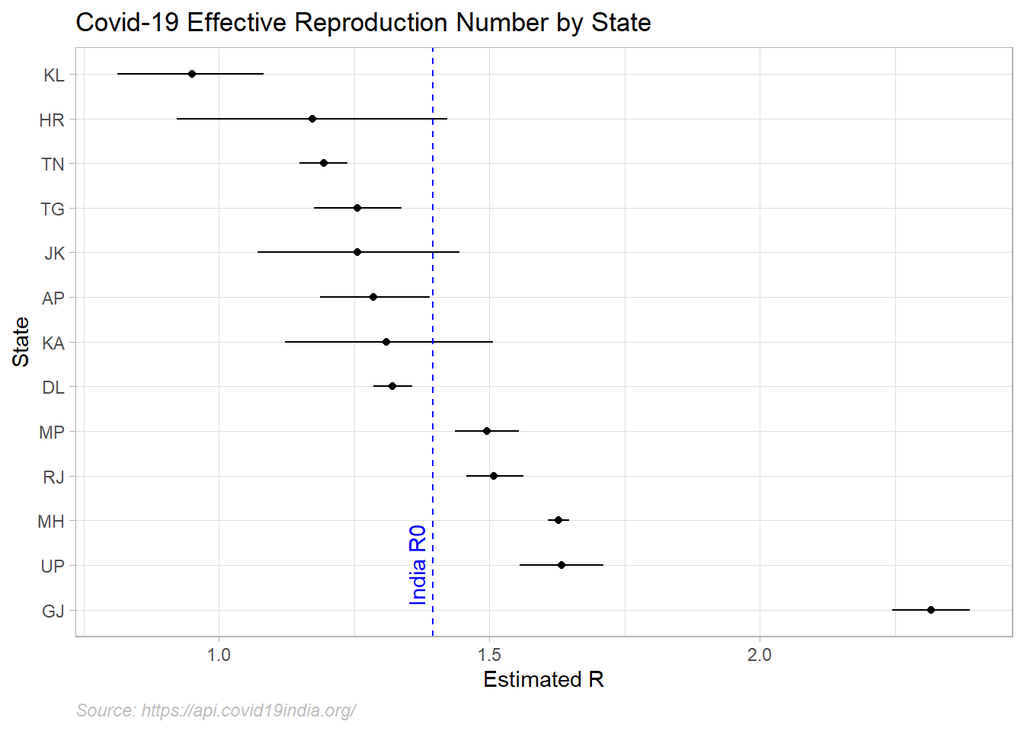

```r
df_ind_coeff <- coeffs %>%
    filter(state != "Population")

pop_coeff <- coeffs %>%
    filter(state == "Population")

df_ind_coeff <- df_ind_coeff %>%
    filter(abs(HI - LI) < 0.5)

# reording based on R0 size
df_ind_coeff$state_ro <- transform(df_ind_coeff$state,
                                   state_ro=reorder(df_ind_coeff$state,
                                                    -df_ind_coeff$Median))$state_ro

# Plotting Rs
df_ind_coeff %>%
    arrange(Median) %>%
    ggplot(aes(x=state_ro,y=Median))+
    geom_point() +
    geom_linerange(aes(ymin=LI,ymax=HI)) +
    geom_hline(data=pop_coeff,
                 aes(yintercept=Median),
                 color="blue",linetype="dashed") +
    annotate("text", y=pop_coeff$Median - 0.03, x = 2, label= "India R0",
             color = "blue", angle = 90) +
    coord_flip() +
      labs(title = "Covid-19 Effective Reproduction Number by State",
           y = "Estimated R",
           x = "State",
           caption = "Source: https://api.covid19india.org/") +
    theme(plot.caption = element_text(color = "grey",
                                      face = "italic",
                                      hjust = 0))
```

```r
ggsave("./simple_heir/r0_bysate.png",
       height = 6, width = 9)
```